# Мониторинг в сетях

SNMP, агенты, Zabbix, Nagios

Суннатилло Махмудов

22 апреля 2026

# Цели и задачи работы

## Цель работы

- Изучить назначение мониторинга в сетях
- Рассмотреть принципы работы **SNMP**
- Определить роль мониторинговых **агентов**
- Сравнить возможности систем **Zabbix** и **Nagios**

## Актуальность темы

- Мониторинг позволяет своевременно выявлять:
  - отказы оборудования
  - деградацию производительности
  - ошибки на интерфейсах и каналах связи
  - недоступность сервисов
- Без мониторинга администратор узнаёт о проблеме уже после её влияния на пользователей

# Теоретические сведения

## Значение мониторинга в сетевой инфраструктуре

- Мониторинг — это регулярное наблюдение за:
  - узлами сети
  - каналами связи
  - сервисами
  - прикладными компонентами
- Основная задача:
  - вовремя обнаруживать сбои и аномалии
- Практический эффект:
  - контроль доступности
  - анализ истории событий
  - получение уведомлений о проблемах

## Почему мониторинг особенно важен для сети

- Для сетевой инфраструктуры критичны:
  - доступность маршрутизаторов и коммутаторов
  - состояние интерфейсов
  - уровень ошибок
  - задержки и потери пакетов
  - загрузка каналов
  - работоспособность сетевых сервисов
- Постоянное наблюдение уменьшает время реакции на инциденты

# SNMP как базовый протокол мониторинга

## Что такое SNMP

- **SNMP** (*Simple Network Management Protocol*) — базовый протокол сетевого мониторинга
- Позволяет:
  - просматривать параметры устройства
  - изменять часть управляющей информации
- Основа архитектуры:
  - **менеджер**
  - **агент**
  - **MIB** (*Management Information Base*)

## Архитектура взаимодействия SNMP

- **Менеджер** опрашивает управляемое устройство
- **Агент** предоставляет доступ к данным устройства
- Данные организованы как объекты **MIB**
- MIB описывает:
  - интерфейсы
  - счётчики
  - таблицы
  - другие параметры узла

## Архитектура взаимодействия SNMP

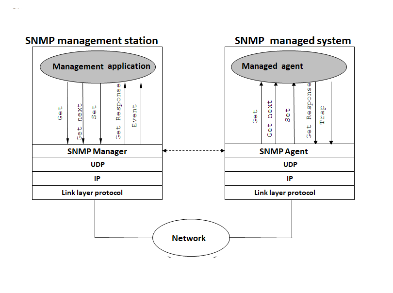

Архитектура взаимодействия менеджера SNMP и управляемого узла

## Основные операции SNMP

- Операции чтения:
  - `GetRequest`
  - `GetNextRequest`
  - `GetBulkRequest`
- Операция изменения:
  - `SetRequest`
- Ответ агента:
  - `Response`
- Уведомления от агента:
  - `Trap`
  - `Inform`

## Основные операции SNMP

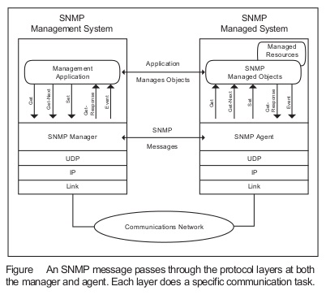

Базовые операции и обмен сообщениями в SNMP

## Порты и безопасность SNMP

- Стандартные порты:
  - **161/UDP** — запросы менеджера к агенту
  - **162/UDP** — ловушки и уведомления
- Версии протокола:
  - **SNMPv1 / SNMPv2c** — простые, но слабее по защите
  - **SNMPv3** — поддерживает аутентификацию и защиту сообщений
- Для реальной эксплуатации предпочтителен **SNMPv3**

# Агенты мониторинга

## Роль мониторинговых агентов

- Агент — это программный компонент на устройстве или сервере
- Он собирает локальные показатели и передаёт их в систему мониторинга
- Агент нужен для получения метрик, которые трудно собрать извне:
  - загрузка CPU
  - использование памяти
  - состояние процессов и служб
  - журналы и внутренние метрики приложений

## Агентный и безагентный подход

- **Сетевые устройства** часто публикуют данные через встроенный **SNMP-агент**
- **Серверы и рабочие станции** удобнее контролировать через специализированные агенты
- Агентный подход:
  - расширяет наблюдаемость
  - не заменяет SNMP, а дополняет его
- В разных системах мониторинга агенты и плагины реализованы по-разному

# Zabbix как интегрированная система мониторинга

## Архитектура Zabbix

- **Zabbix** — интегрированная платформа мониторинга
- Основные компоненты:
  - **Zabbix Server**
  - **база данных**
  - **веб-интерфейс**
  - **Proxy**
  - **агенты**
- Система объединяет сбор, хранение, анализ, визуализацию и уведомления

## Архитектура Zabbix

[figure not shown]

Базовая архитектура Zabbix

## Возможности Zabbix

- Поддерживает:
  - собственных агентов
  - **SNMP v1/v2c/v3**
  - **SNMP traps**
  - **IPMI**
  - **JMX**
  - web monitoring
- Преимущества:
  - единая архитектура
  - централизованное управление
  - шаблоны
  - карты сети
  - графики и триггеры
  - удобное масштабирование

# Nagios как модульная система мониторинга

## Архитектура Nagios

- **Nagios Core** строится вокруг ядра мониторинга
- Ядро отвечает за:
  - расписание проверок
  - обработку результатов
  - отслеживание состояний
  - уведомления
- Сами проверки выполняются внешними **плагинами**

## Особенности Nagios

- Основной акцент сделан на:
  - модульность
  - расширяемость
  - пользовательские проверки
- Для удалённых Linux/Unix-хостов часто используется **NRPE**
- NRPE позволяет выполнять проверки на удалённой машине и возвращать результат серверу Nagios

## Особенности Nagios

[figure not shown]

Основной экран Nagios Core

# Сравнение Zabbix и Nagios

## Zabbix и Nagios: сравнительная характеристика

| Критерий | Zabbix | Nagios |
| --- | --- | --- |
| Архитектура | Единая интегрированная платформа | Ядро + плагины + дополнения |
| Сбор данных | Агенты, SNMP, IPMI, JMX, web monitoring | Плагины, NRPE, SNMP, удалённые проверки |
| Централизованное управление | Высокое | Зависит от конфигурации и расширений |
| Гибкость расширения | Высокая в рамках платформы | Очень высокая за счёт плагинов |
| Типичный сценарий | Крупная централизованная инфраструктура | Нестандартные и сильно кастомизируемые среды |

## Итоги сравнения

- **Zabbix** удобен, когда важны:
  - целостная архитектура
  - единое управление
  - готовые средства визуализации и шаблоны
- **Nagios** удобен, когда важны:
  - модульность
  - гибкая интеграция
  - собственные специализированные проверки

# Выводы

## Вывод

- Мониторинг — необходимый элемент эксплуатации современной сетевой инфраструктуры
- **SNMP** остаётся базовым протоколом сетевого наблюдения
- **Агенты** позволяют получать внутренние метрики серверов и приложений
- **Zabbix** ориентирован на интеграцию и централизованное управление
- **Nagios** ориентирован на модульность и расширяемость
- Выбор между ними зависит от требований:
  - либо более цельная платформа
  - либо более гибкая плагинная архитектура

## Спасибо за внимание

- Вопросы?